# Part I - Prosper Loan Data

## by RANDRIANIRINA Ghislain Brice

## Preliminary Wrangling

```python
# import all packages and set plots to be embedded inline
import numpy as np
import pandas as pd
import matplotlib.pyplot as plt
import seaborn as sb
%matplotlib inline
```

### load data into dataframe

```python
# load data into dataframe

loan = pd.read_csv('prosperLoanData.csv')
```

### How many features and observations of them do we have?

```python
# overiview of data shape

print(f'The loan data contain {loan.shape[0]} observations and {loan.shape[1]} features')
```

```
The loan data contain 113937 observations and 81 features
```

### How the composition of the data looks like?

```python
# overiview of composition

loan.head()
```

|  | ListingKey | ListingNumber | ListingCreationDate | CreditGrade | Term | LoanStatus | ClosedDate | BorrowerAPR | BorrowerRate | LenderYield | ... | LP_ServiceFees | LP_CollectionFees | LP_GrossPrincipalLoss | LP_NetPrincipalLoss | LP_NonPrincipalRecoverypayments | PercentFunded | Recommendations | InvestmentFromFriendsCount | InvestmentFromFriendsAmount | Investors |
| --- | --- | --- | --- | --- | --- | --- | --- | --- | --- | --- | --- | --- | --- | --- | --- | --- | --- | --- | --- | --- | --- |
| 0 | 1021339766868145413AB3B | 193129 | 2007-08-26 19:09:29.263000000 | C | 36 | Completed | 2009-08-14 00:00:00 | 0.16516 | 0.1580 | 0.1380 | ... | -133.18 | 0.0 | 0.0 | 0.0 | 0.0 | 1.0 | 0 | 0 | 0.0 | 258 |
| 1 | 10273602499503308B223C1 | 1209647 | 2014-02-27 08:28:07.900000000 | NaN | 36 | Current | NaN | 0.12016 | 0.0920 | 0.0820 | ... | 0.00 | 0.0 | 0.0 | 0.0 | 0.0 | 1.0 | 0 | 0 | 0.0 | 1 |
| 2 | 0EE9337825851032864889A | 81716 | 2007-01-05 15:00:47.090000000 | HR | 36 | Completed | 2009-12-17 00:00:00 | 0.28269 | 0.2750 | 0.2400 | ... | -24.20 | 0.0 | 0.0 | 0.0 | 0.0 | 1.0 | 0 | 0 | 0.0 | 41 |
| 3 | 0EF5356002482715299901A | 658116 | 2012-10-22 11:02:35.010000000 | NaN | 36 | Current | NaN | 0.12528 | 0.0974 | 0.0874 | ... | -108.01 | 0.0 | 0.0 | 0.0 | 0.0 | 1.0 | 0 | 0 | 0.0 | 158 |
| 4 | 0F023589499656230C5E3E2 | 909464 | 2013-09-14 18:38:39.097000000 | NaN | 36 | Current | NaN | 0.24614 | 0.2085 | 0.1985 | ... | -60.27 | 0.0 | 0.0 | 0.0 | 0.0 | 1.0 | 0 | 0 | 0.0 | 20 |

5 rows × 81 columns

### How many misssing values per attribute the data have ?

```python
# Let's count the missing values

loan.isna().sum()
```

```
ListingKey                                  0
ListingNumber                               0
ListingCreationDate                         0
CreditGrade                             84984
Term                                        0
LoanStatus                                  0
ClosedDate                              58848
BorrowerAPR                                25
BorrowerRate                                0
LenderYield                                 0
EstimatedEffectiveYield                 29084
EstimatedLoss                           29084
EstimatedReturn                         29084
ProsperRating (numeric)                 29084
ProsperRating (Alpha)                   29084
ProsperScore                            29084
ListingCategory (numeric)                   0
BorrowerState                            5515
Occupation                               3588
EmploymentStatus                         2255
EmploymentStatusDuration                 7625
IsBorrowerHomeowner                         0
CurrentlyInGroup                            0
GroupKey                               100596
DateCreditPulled                            0
CreditScoreRangeLower                     591
CreditScoreRangeUpper                     591
FirstRecordedCreditLine                   697
CurrentCreditLines                       7604
OpenCreditLines                          7604
                                        ...
TotalProsperLoans                       91852
TotalProsperPaymentsBilled              91852
OnTimeProsperPayments                   91852
ProsperPaymentsLessThanOneMonthLate     91852
ProsperPaymentsOneMonthPlusLate         91852
ProsperPrincipalBorrowed                91852
ProsperPrincipalOutstanding             91852
ScorexChangeAtTimeOfListing             95009
LoanCurrentDaysDelinquent                   0
LoanFirstDefaultedCycleNumber           96985
LoanMonthsSinceOrigination                  0
LoanNumber                                  0
LoanOriginalAmount                          0
LoanOriginationDate                         0
LoanOriginationQuarter                      0
MemberKey                                   0
MonthlyLoanPayment                          0
LP_CustomerPayments                         0
LP_CustomerPrincipalPayments                0
LP_InterestandFees                          0
LP_ServiceFees                              0
LP_CollectionFees                           0
LP_GrossPrincipalLoss                       0
LP_NetPrincipalLoss                         0
LP_NonPrincipalRecoverypayments             0
PercentFunded                               0
Recommendations                             0
InvestmentFromFriendsCount                  0
InvestmentFromFriendsAmount                 0
Investors                                   0
Length: 81, dtype: int64
```

### save the count of missing values in a dataframe

```python
# save the missing value counts in dataframe

loan_missing_values = loan.isna().sum().reset_index(name = 'count')
loan_missing_values.rename(columns = {'index':'features'}, inplace = True)
loan_missing_values
```

|  | features | count |
| --- | --- | --- |
| 0 | ListingKey | 0 |
| 1 | ListingNumber | 0 |
| 2 | ListingCreationDate | 0 |
| 3 | CreditGrade | 84984 |
| 4 | Term | 0 |
| 5 | LoanStatus | 0 |
| 6 | ClosedDate | 58848 |
| 7 | BorrowerAPR | 25 |
| 8 | BorrowerRate | 0 |
| 9 | LenderYield | 0 |
| 10 | EstimatedEffectiveYield | 29084 |
| 11 | EstimatedLoss | 29084 |
| 12 | EstimatedReturn | 29084 |
| 13 | ProsperRating (numeric) | 29084 |
| 14 | ProsperRating (Alpha) | 29084 |
| 15 | ProsperScore | 29084 |
| 16 | ListingCategory (numeric) | 0 |
| 17 | BorrowerState | 5515 |
| 18 | Occupation | 3588 |
| 19 | EmploymentStatus | 2255 |
| 20 | EmploymentStatusDuration | 7625 |
| 21 | IsBorrowerHomeowner | 0 |
| 22 | CurrentlyInGroup | 0 |
| 23 | GroupKey | 100596 |
| 24 | DateCreditPulled | 0 |
| 25 | CreditScoreRangeLower | 591 |
| 26 | CreditScoreRangeUpper | 591 |
| 27 | FirstRecordedCreditLine | 697 |
| 28 | CurrentCreditLines | 7604 |
| 29 | OpenCreditLines | 7604 |
| ... | ... | ... |
| 51 | TotalProsperLoans | 91852 |
| 52 | TotalProsperPaymentsBilled | 91852 |
| 53 | OnTimeProsperPayments | 91852 |
| 54 | ProsperPaymentsLessThanOneMonthLate | 91852 |
| 55 | ProsperPaymentsOneMonthPlusLate | 91852 |
| 56 | ProsperPrincipalBorrowed | 91852 |
| 57 | ProsperPrincipalOutstanding | 91852 |
| 58 | ScorexChangeAtTimeOfListing | 95009 |
| 59 | LoanCurrentDaysDelinquent | 0 |
| 60 | LoanFirstDefaultedCycleNumber | 96985 |
| 61 | LoanMonthsSinceOrigination | 0 |
| 62 | LoanNumber | 0 |
| 63 | LoanOriginalAmount | 0 |
| 64 | LoanOriginationDate | 0 |
| 65 | LoanOriginationQuarter | 0 |
| 66 | MemberKey | 0 |
| 67 | MonthlyLoanPayment | 0 |
| 68 | LP_CustomerPayments | 0 |
| 69 | LP_CustomerPrincipalPayments | 0 |
| 70 | LP_InterestandFees | 0 |
| 71 | LP_ServiceFees | 0 |
| 72 | LP_CollectionFees | 0 |
| 73 | LP_GrossPrincipalLoss | 0 |
| 74 | LP_NetPrincipalLoss | 0 |
| 75 | LP_NonPrincipalRecoverypayments | 0 |
| 76 | PercentFunded | 0 |
| 77 | Recommendations | 0 |
| 78 | InvestmentFromFriendsCount | 0 |
| 79 | InvestmentFromFriendsAmount | 0 |
| 80 | Investors | 0 |

81 rows × 2 columns

### How many attributes left if we keep data having some percentage of missing values?

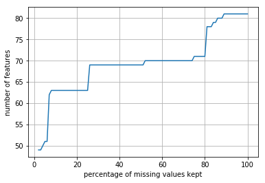

```
So there are 51 attributes left if we keep data having missing values less than or equal to 5 percent of observations
```

```python
# Let's plot the number of attributes vs percentage of missing values kept

N = [] # nb of features
n = [] # percentage of observations

for i in range(100, 1,-1):
    df = loan_missing_values[loan_missing_values['count']<=(i)*len(loan)/100]
    N.append(len(df))
    n.append(i)

plt.plot(n,N)
plt.grid()
plt.xlabel('percentage of missing values kept')
plt.ylabel('number of features')
plt.show()

accepted_missing = 5
df = loan_missing_values[loan_missing_values['count']<=accepted_missing*len(loan)/100]
print(f'So there are {len(df)} attributes left if we keep data having missing values less than or equal to {accepted_missing} percent of observations')
```

### List of features where missing values are less than or equal to 5 percent of observations

```python
# All features where missing values count are less than or equal to 5 percent of observation

list_5 = list(df['features'].unique())
list_5
```

```
['ListingKey',
 'ListingNumber',
 'ListingCreationDate',
 'Term',
 'LoanStatus',
 'BorrowerAPR',
 'BorrowerRate',
 'LenderYield',
 'ListingCategory (numeric)',
 'BorrowerState',
 'Occupation',
 'EmploymentStatus',
 'IsBorrowerHomeowner',
 'CurrentlyInGroup',
 'DateCreditPulled',
 'CreditScoreRangeLower',
 'CreditScoreRangeUpper',
 'FirstRecordedCreditLine',
 'TotalCreditLinespast7years',
 'OpenRevolvingAccounts',
 'OpenRevolvingMonthlyPayment',
 'InquiriesLast6Months',
 'TotalInquiries',
 'CurrentDelinquencies',
 'DelinquenciesLast7Years',
 'PublicRecordsLast10Years',
 'IncomeRange',
 'IncomeVerifiable',
 'StatedMonthlyIncome',
 'LoanKey',
 'LoanCurrentDaysDelinquent',
 'LoanMonthsSinceOrigination',
 'LoanNumber',
 'LoanOriginalAmount',
 'LoanOriginationDate',
 'LoanOriginationQuarter',
 'MemberKey',
 'MonthlyLoanPayment',
 'LP_CustomerPayments',
 'LP_CustomerPrincipalPayments',
 'LP_InterestandFees',
 'LP_ServiceFees',
 'LP_CollectionFees',
 'LP_GrossPrincipalLoss',
 'LP_NetPrincipalLoss',
 'LP_NonPrincipalRecoverypayments',
 'PercentFunded',
 'Recommendations',
 'InvestmentFromFriendsCount',
 'InvestmentFromFriendsAmount',
 'Investors']
```

### Loan data with features where missing values are less than or equal to 5 percent of observations

```python
# we will keep only loan data where features have missing values less than or equal to 5 percent of observations

loan_5 = loan[list_5]
loan_5.shape
```

```
(113937, 51)
```

### Let's remove all rows having missing values

```python
# removing rows having missing values

loan_5 = loan_5.dropna()
loan_5.shape
```

```
(106159, 51)
```

### No more missing values ?

```python
# check if there are still missing values

loan_5.isnull().sum()
```

```
ListingKey                         0
ListingNumber                      0
ListingCreationDate                0
Term                               0
LoanStatus                         0
BorrowerAPR                        0
BorrowerRate                       0
LenderYield                        0
ListingCategory (numeric)          0
BorrowerState                      0
Occupation                         0
EmploymentStatus                   0
IsBorrowerHomeowner                0
CurrentlyInGroup                   0
DateCreditPulled                   0
CreditScoreRangeLower              0
CreditScoreRangeUpper              0
FirstRecordedCreditLine            0
TotalCreditLinespast7years         0
OpenRevolvingAccounts              0
OpenRevolvingMonthlyPayment        0
InquiriesLast6Months               0
TotalInquiries                     0
CurrentDelinquencies               0
DelinquenciesLast7Years            0
PublicRecordsLast10Years           0
IncomeRange                        0
IncomeVerifiable                   0
StatedMonthlyIncome                0
LoanKey                            0
LoanCurrentDaysDelinquent          0
LoanMonthsSinceOrigination         0
LoanNumber                         0
LoanOriginalAmount                 0
LoanOriginationDate                0
LoanOriginationQuarter             0
MemberKey                          0
MonthlyLoanPayment                 0
LP_CustomerPayments                0
LP_CustomerPrincipalPayments       0
LP_InterestandFees                 0
LP_ServiceFees                     0
LP_CollectionFees                  0
LP_GrossPrincipalLoss              0
LP_NetPrincipalLoss                0
LP_NonPrincipalRecoverypayments    0
PercentFunded                      0
Recommendations                    0
InvestmentFromFriendsCount         0
InvestmentFromFriendsAmount        0
Investors                          0
dtype: int64
```

### Attributes choice for analysis

```python
# we choose few attributes among the list above for the analysis

last_features = [
 'Term',
 'LoanStatus',
 'BorrowerAPR',
 'BorrowerRate',
 'ListingCategory (numeric)',
 'Occupation',
    'LoanOriginalAmount',
 'EmploymentStatus',
 'IsBorrowerHomeowner',
 'StatedMonthlyIncome',
 'MonthlyLoanPayment',
 'Investors'
                ]
loan_clean = loan_5[last_features]
loan_clean.head()
```

|  | Term | LoanStatus | BorrowerAPR | BorrowerRate | ListingCategory (numeric) | Occupation | LoanOriginalAmount | EmploymentStatus | IsBorrowerHomeowner | StatedMonthlyIncome | MonthlyLoanPayment | Investors |
| --- | --- | --- | --- | --- | --- | --- | --- | --- | --- | --- | --- | --- |
| 0 | 36 | Completed | 0.16516 | 0.1580 | 0 | Other | 9425 | Self-employed | True | 3083.333333 | 330.43 | 258 |
| 1 | 36 | Current | 0.12016 | 0.0920 | 2 | Professional | 10000 | Employed | False | 6125.000000 | 318.93 | 1 |
| 2 | 36 | Completed | 0.28269 | 0.2750 | 0 | Other | 3001 | Not available | False | 2083.333333 | 123.32 | 41 |
| 3 | 36 | Current | 0.12528 | 0.0974 | 16 | Skilled Labor | 10000 | Employed | True | 2875.000000 | 321.45 | 158 |
| 4 | 36 | Current | 0.24614 | 0.2085 | 2 | Executive | 15000 | Employed | True | 9583.333333 | 563.97 | 20 |

### check if data some datatypes need to be converted

```python
# overiview of  datatype

loan_clean.info()
print('\nSome categorical variables type need to be converted from "object/numeric" type to "categorical" type')
```

```
<class 'pandas.core.frame.DataFrame'>
Int64Index: 106159 entries, 0 to 113936
Data columns (total 12 columns):
Term                         106159 non-null int64
LoanStatus                   106159 non-null object
BorrowerAPR                  106159 non-null float64
BorrowerRate                 106159 non-null float64
ListingCategory (numeric)    106159 non-null int64
Occupation                   106159 non-null object
LoanOriginalAmount           106159 non-null int64
EmploymentStatus             106159 non-null object
IsBorrowerHomeowner          106159 non-null bool
StatedMonthlyIncome          106159 non-null float64
MonthlyLoanPayment           106159 non-null float64
Investors                    106159 non-null int64
dtypes: bool(1), float64(4), int64(4), object(3)
memory usage: 9.8+ MB

Some categorical variables type need to be converted from "object/numeric" type to "categorical" type
```

### Data type conversion

```python
# change 'LoanStatus', 'Occupation', 'EmploymentStatus' type from 'object' to 'category'

categories = ['LoanStatus', 'Occupation', 'EmploymentStatus', 'ListingCategory (numeric)']
loan_clean[categories] = loan_clean[categories].astype('category')
```

```python
# check if conversion is done
loan_clean.info()
```

```
<class 'pandas.core.frame.DataFrame'>
Int64Index: 106159 entries, 0 to 113936
Data columns (total 12 columns):
Term                         106159 non-null int64
LoanStatus                   106159 non-null category
BorrowerAPR                  106159 non-null float64
BorrowerRate                 106159 non-null float64
ListingCategory (numeric)    106159 non-null category
Occupation                   106159 non-null category
LoanOriginalAmount           106159 non-null int64
EmploymentStatus             106159 non-null category
IsBorrowerHomeowner          106159 non-null bool
StatedMonthlyIncome          106159 non-null float64
MonthlyLoanPayment           106159 non-null float64
Investors                    106159 non-null int64
dtypes: bool(1), category(4), float64(4), int64(3)
memory usage: 7.0 MB
```

### descriptive statistic

```python
# descriptive statistic for numeric variables

numeric_count = -1
numeric_features = []
for col in loan_clean.columns:
    if loan_clean[col].dtypes in ['float64', 'int64']:
        numeric_count +=1
        numeric_features.append(loan_clean[col].describe())
        print(numeric_features[numeric_count], '\n')
print(f'There are {numeric_count+1} numeric attributes')
```

```
count    106159.000000
mean         41.125595
std          10.689162
min          12.000000
25%          36.000000
50%          36.000000
75%          36.000000
max          60.000000
Name: Term, dtype: float64

count    106159.000000
mean          0.220429
std           0.081007
min           0.006530
25%           0.157130
50%           0.211320
75%           0.287040
max           0.423950
Name: BorrowerAPR, dtype: float64

count    106159.000000
mean          0.193462
std           0.075397
min           0.000000
25%           0.134000
50%           0.184000
75%           0.253700
max           0.360000
Name: BorrowerRate, dtype: float64

count    106159.000000
mean       8530.504008
std        6283.458769
min        1000.000000
25%        4000.000000
50%        7000.000000
75%       12000.000000
max       35000.000000
Name: LoanOriginalAmount, dtype: float64

```

[output cut: 16 more lines]

```
75%         377.000000
max        2251.510000
Name: MonthlyLoanPayment, dtype: float64

count    106159.000000
mean         81.348477
std         104.510748
min           1.000000
25%           1.000000
50%          44.000000
75%         117.000000
max        1189.000000
Name: Investors, dtype: float64

There are 7 numeric attributes
```

### What is the structure of your dataset?

> The Prosper loan dataset contain 113937 loans with 81 features where 60 are numerics and 21 non-numerics (categorical, date).

### What is/are the main feature(s) of interest in your dataset?

> I will focus on the features that affect the most the **Borrower's Annual Percentage Rate** in the dataset.

### What features in the dataset do you think will help support your investigation into your feature(s) of interest?

> I await the **borrower interest** and **loan amount** have a strongest impact on the loan rate. However, I will inspect other features during the exploration.

## Univariate Exploration

### Define univariate/bivariate functions

```python
def dynamic_subplot(n):
    v=np.sqrt(n)
    m=round(np.sqrt(n))
    p=round(n/m)
    if m*p < n:
        p += 1
    return (p,m)

def plot_numeric(data, numeric, size_label, size_ticks, percent):
    span = data[numeric].max() - data[numeric].min()
    bins = np.arange(0, data[numeric].max()+span*percent/100, span*percent/100)
    plt.hist(data = data, x = numeric, bins = bins)
    plt.xlabel(numeric, size = size_label)
    plt.ylabel('count', size = size_label)
    plt.xticks(size = size_ticks);
    plt.yticks(size = size_ticks)

def plot_categorical_ord(data, categorical, size_label, size_ticks):
    base_color = sb.color_palette()[0]
    sb.countplot(data=data, y=categorical, color=base_color);
    plt.ylabel(categorical, size = size_label)
    plt.xlabel('count', size = size_label)
    plt.xticks(size = size_ticks)
    plt.yticks(size = size_ticks);

def plot_categorical_nom(data, categorical, size_label, size_ticks):
    base_color = sb.color_palette()[0]
    freq = data[categorical].value_counts()
    cat_order = freq.index
    sb.countplot(data=data, y=categorical, color=base_color, order = cat_order);
    plt.ylabel(categorical, size = size_label)
    plt.xlabel('count', size = size_label)
    plt.xticks(size = size_ticks)
    plt.yticks(size = size_ticks);

def plot_log(data, numeric, size_label, size_ticks, percent):

    mini = np.log10(data[numeric].min())
    maxi = np.log10(data[numeric].max())
    span = maxi - mini

    # Bin size
    bins = 10 ** np.arange(mini, maxi+percent*span/100, percent*span/100)
    plt.hist(data=data, x=numeric, bins=bins);

    plt.xscale('log')
    # Apply x-axis label
    plt.xlabel(numeric, size = size_label)
    plt.ylabel('count', size = size_label)
    plt.xticks(size = size_ticks)
    plt.yticks(size = size_ticks);

def plot_num_vs_cat(data, categorical, numeric, size_label, size_ticks):
    base_color = sb.color_palette()[0]
    sb.boxplot(data=data, y=categorical, x=numeric, color = base_color)
    plt.xticks(rotation = 45);
    plt.xlabel(numeric, size = size_label)
    plt.ylabel(categorical, size = size_label)
    plt.xticks(size = size_ticks)
    plt.yticks(size = size_ticks);
```

### Nnumerical attributes

```python
# collect all numerical attributes
numeric_attr = []
for col in loan_clean.columns:
    if loan_clean[col].dtypes in ['float64', 'int64']:
        numeric_attr.append(col)
```

### Histogram for all numerical attributes

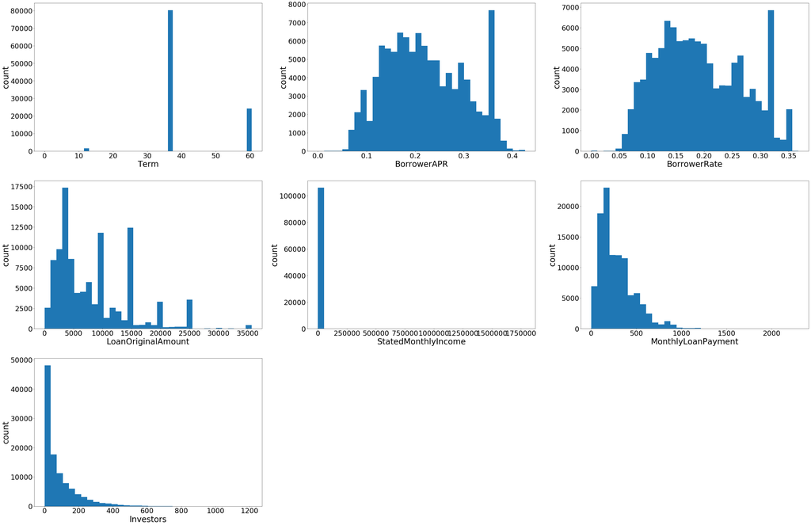

```python
# plot histogram for all numerical attributes
plt.figure(figsize = [60,40])

grids = dynamic_subplot(len(numeric_attr))

for i in np.arange(len(numeric_attr)):

    plt.subplot(grids[0],grids[1], i+1)
    plot_numeric(loan_clean, numeric_attr[i], 35, 30,3)
```

> - Investors, Monthly Loan Payment, Stated Monthly Income and Loan Original Amount are right skweed.
> - Loan Original Amount have pattern such as spike then skween righ, then a spike skween righ, and so on.
> - Most of the borrowers choose 36 months term.
> - There is an unexpected high count between 0.3 and 0.4 for BorrowerAPR and BorrowerRate distributions even if they are looked slightly righ skweed .

```
(0, 40000)
```

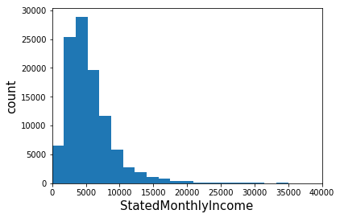

```python
plot_numeric(loan_clean, 'StatedMonthlyIncome', 15, 10, 0.1)
plt.xlim(0, 40000)
```

### Plot 'stated Monthly Income' more than 0 with log transformation, may be they are student or record mistake

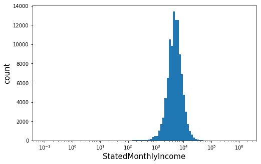

```python
df = loan_clean[loan_clean['StatedMonthlyIncome'] > loan_clean['StatedMonthlyIncome'].min()]
plt.figure(figsize = [8,5])
plot_log(df, 'StatedMonthlyIncome', 15, 10, 1)
```